# Nour2610: Traffic Data Analysis

```r
library(reshape2)
library(ggplot2)
library(dplyr)
library(tidyr)
```

```r
mydata <- read.csv("../all-semi-unique.csv")
nrow(mydata)
```

```
## [1] 429982
```

```r
ncol(mydata)
```

```
## [1] 34
```

```r
names(mydata)
```

```
##  [1] "crawl_date"      "ad.aid"          "ad.bgcl"
##  [4] "ad.bgcls"        "ad.fncl"         "ad.fncls"
##  [7] "ad.lid"          "ad.logo"         "ad.logo2x"
## [10] "ad.logoAndroidS" "ad.logoAndroidH" "ad.cm"
## [13] "ad.url"          "ad.g"            "rd.nm"
## [16] "rd.ri"           "rd.stid"         "rd.hr"
## [19] "rd.mn"           "rd.new"          "rd.img"
## [22] "rd.cl"           "rd.strq"         "rd.cmrq"
## [25] "rd.rp.nm"        "rd.rp.fullnm"    "rd.rp.hr"
## [28] "rd.rp.mn"        "rd.rp.stid"      "rd.rp.cm"
## [31] "rd.rp.cmid"      "rd.rp.rpImg"     "rd.rp.img"
## [34] "rd.rp.type"
```

```r
head(mydata)
```

```
##                     crawl_date ad.aid ad.bgcl ad.bgcls ad.fncl ad.fncls
## 1 Fri Feb  5 17:23:57 UTC 2016   2538 #003768  #0069aa #FFFFFF  #FFFFFF
## 2 Fri Feb  5 17:23:57 UTC 2016   2538 #003768  #0069aa #FFFFFF  #FFFFFF
## 3 Fri Feb  5 17:23:57 UTC 2016   2538 #003768  #0069aa #FFFFFF  #FFFFFF
## 4 Fri Feb  5 17:23:57 UTC 2016   2538 #003768  #0069aa #FFFFFF  #FFFFFF
## 5 Sat Feb  6 08:01:00 UTC 2016   2538 #003768  #0069aa #FFFFFF  #FFFFFF
## 6 Sat Feb  6 08:01:00 UTC 2016   2538 #003768  #0069aa #FFFFFF  #FFFFFF
##   ad.lid                                                  ad.logo
## 1   1001 http://www.bey2ollak.com/downloads/logos/Pepsi_SA7EL.png
## 2   1001 http://www.bey2ollak.com/downloads/logos/Pepsi_SA7EL.png
## 3   1001 http://www.bey2ollak.com/downloads/logos/Pepsi_SA7EL.png
## 4   1001 http://www.bey2ollak.com/downloads/logos/Pepsi_SA7EL.png
## 5   1001 http://www.bey2ollak.com/downloads/logos/Pepsi_SA7EL.png
## 6   1001 http://www.bey2ollak.com/downloads/logos/Pepsi_SA7EL.png
##                                                     ad.logo2x
```

[output cut: 62 more lines]

```r
summary(mydata)
```

```
##                         crawl_date         ad.aid        ad.bgcl
##  Sun Feb 14 22:30:08 UTC 2016:   120   Min.   :2538   #003768:429982
##  Sun Feb 14 22:30:10 UTC 2016:   120   1st Qu.:2538
##  Sun Feb 14 22:30:11 UTC 2016:   120   Median :2538
##  Sun Feb 14 22:30:14 UTC 2016:   120   Mean   :2538
##  Sun Feb 14 22:30:15 UTC 2016:   120   3rd Qu.:2538
##  Sun Feb 14 23:00:09 UTC 2016:   120   Max.   :2538
##  (Other)                     :429262
##     ad.bgcls         ad.fncl          ad.fncls          ad.lid
##  #0069aa:429982   #FFFFFF:429982   #FFFFFF:429982   Min.   :1001
##                                                     1st Qu.:1001
##                                                     Median :1001
##                                                     Mean   :1001
##                                                     3rd Qu.:1001
##                                                     Max.   :1001
##
##                                                      ad.logo
##  http://www.bey2ollak.com/downloads/logos/Pepsi_SA7EL.png:429982
##
##
##
##
##
##
##                                                        ad.logo2x
##  http://www.bey2ollak.com/downloads/logos/Pepsi_SA7EL@2x.png:429982
##
##
##
##
##
##
##                                                            ad.logoAndroidS
##  http://www.bey2ollak.com/downloads/logos/Pepsi_SA7EL_ANDROID_S.png:429982
##
##
##
##
##
##
```

[output cut: 57 more lines]

```
##  Min.   : 0.0   Min.   : 1.00   lazeez       : 76106   Min.   :9271509
##  1st Qu.:14.0   1st Qu.: 2.00   mashy        : 21710   1st Qu.:9338581
##  Median :29.0   Median : 3.00   7alawa       : 16996   Median :9376096
##  Mean   :29.2   Mean   : 4.71   za7ma        : 14183   Mean   :9376278
##  3rd Qu.:44.0   3rd Qu.:10.00   Eih el nezam?: 14127   3rd Qu.:9413977
##  Max.   :59.0   Max.   :10.00   mafeesh amal :  7904   Max.   :9452302
##                 NA's   :13965   (Other)      :278956
##   rd.rp.rpImg       rd.rp.img        rd.rp.type
##  Min.   : 21970   Min.   :    50   Min.   :0
##  1st Qu.:458600   1st Qu.: 62923   1st Qu.:0
##  Median :461455   Median : 62923   Median :0
##  Mean   :461014   Mean   :146707   Mean   :0
##  3rd Qu.:464205   3rd Qu.:233366   3rd Qu.:0
##  Max.   :467309   Max.   :467247   Max.   :0
##  NA's   :411585   NA's   :152557
```

Having a look at the internal structure and types of the columns.

```r
str(mydata)
```

```
## 'data.frame':    429982 obs. of  34 variables:
##  $ crawl_date     : Factor w/ 28331 levels "Fri Feb 12 00:00:14 UTC 2016",..: 1869 1869 1869 1869 8758 8758 8809 8809 8862 8862 ...
##  $ ad.aid         : int  2538 2538 2538 2538 2538 2538 2538 2538 2538 2538 ...
##  $ ad.bgcl        : Factor w/ 1 level "#003768": 1 1 1 1 1 1 1 1 1 1 ...
##  $ ad.bgcls       : Factor w/ 1 level "#0069aa": 1 1 1 1 1 1 1 1 1 1 ...
##  $ ad.fncl        : Factor w/ 1 level "#FFFFFF": 1 1 1 1 1 1 1 1 1 1 ...
##  $ ad.fncls       : Factor w/ 1 level "#FFFFFF": 1 1 1 1 1 1 1 1 1 1 ...
##  $ ad.lid         : int  1001 1001 1001 1001 1001 1001 1001 1001 1001 1001 ...
##  $ ad.logo        : Factor w/ 1 level "http://www.bey2ollak.com/downloads/logos/Pepsi_SA7EL.png": 1 1 1 1 1 1 1 1 1 1 ...
##  $ ad.logo2x      : Factor w/ 1 level "http://www.bey2ollak.com/downloads/logos/Pepsi_SA7EL@2x.png": 1 1 1 1 1 1 1 1 1 1 ...
##  $ ad.logoAndroidS: Factor w/ 1 level "http://www.bey2ollak.com/downloads/logos/Pepsi_SA7EL_ANDROID_S.png": 1 1 1 1 1 1 1 1 1 1 ...
##  $ ad.logoAndroidH: Factor w/ 1 level "http://www.bey2ollak.com/downloads/logos/Pepsi_SA7EL_ANDROID_H.png": 1 1 1 1 1 1 1 1 1 1 ...
##  $ ad.cm          : Factor w/ 1 level "دوس هنا وشوف إعلان بيبسي الجديد مع محمد صلاح #يلا_تقدر": 1 1 1 1 1 1 1 1 1 1 ...
##  $ ad.url         : Factor w/ 1 level "http://youtu.be/aNeqShdgupY": 1 1 1 1 1 1 1 1 1 1 ...
##  $ ad.g           : int  1 1 1 1 1 1 1 1 1 1 ...
```

[output cut: 20 more lines]

All the columns that are of type ‘Factor’ and have only one level are going to be removed, they are not adding any new information to the data or creating patterns. Clean data by removing them. Those columns are : ad.bgcl , ad.bgcls, ad.fncl, ad.fncls, ad.logo, ad.logo2x, ad.logoAndroidS, ad.logoAndroidH, ad.cm, ad.url, rd.cl.

```r
mydata <- subset.data.frame(mydata, select = -c(ad.bgcl , ad.bgcls, ad.fncl, ad.fncls, ad.logo, ad.logo2x, ad.logoAndroidS, ad.logoAndroidH, ad.cm, ad.url, rd.cl))
```

Check if there are still other columns that have no unique values.

```r
col_ct = sapply(mydata, function(x) length(unique(x)))
length(col_ct[col_ct==1])
```

```
## [1] 4
```

```r
names(col_ct[col_ct==1])
```

```
## [1] "ad.aid"     "ad.lid"     "ad.g"       "rd.rp.type"
```

Remove those columns.

```r
mydata = mydata[, !names(mydata) %in% names(col_ct[col_ct==1])]
```

Check for duplicate rows.

```r
nrow(mydata) - nrow(unique(mydata))
```

```
## [1] 0
```

Checking ratio of NAs for every column

```r
sapply(mydata, function(x) sum(is.na(x))/(nrow(mydata)))
```

```
##   crawl_date        rd.nm        rd.ri      rd.stid        rd.hr
##  0.000000000  0.000000000  0.000000000  0.070002930  0.003504798
##        rd.mn       rd.new       rd.img      rd.strq      rd.cmrq
##  0.003504798  0.000000000  0.881883428  0.000000000  0.000000000
##     rd.rp.nm rd.rp.fullnm     rd.rp.hr     rd.rp.mn   rd.rp.stid
##  0.000000000  0.121063207  0.000000000  0.000000000  0.032478104
##     rd.rp.cm   rd.rp.cmid  rd.rp.rpImg    rd.rp.img
##  0.000000000  0.000000000  0.957214488  0.354798573
```

```r
# barplot(sapply(mydata[,1:10], function(col) sum(is.na(col))),xlab = " columns ", ylab = " NA count ")
# barplot(sapply(mydata[,11:19], function(col) sum(is.na(col))),xlab = " columns ", ylab = " NA count ")
```

The values of the image columns have a high ratio of NAs, these images can either be of the user who posted the comment, or a picture they took of the street reported according to the website, do not find it useful, remove it to clear the data.

```r
mydata <- subset.data.frame(mydata, select = -c(rd.rp.rpImg, rd.rp.img, rd.img))
```

Break down the crawl date into date, time. First set crawl date into a time-date context instead of a factor, extract from it the actual time of report using rd.rp.hr and rd.rp.mn which represent elapsed time since the report was posted in UTC, then add 2 hours to obtain cairo time. Then Get the day of week which corresponds to that date, finally get rid of those columns.

```r
mydata$crawl_date <-strptime(mydata$crawl_date, format = "%a %b %e %X UTC %Y", tz = "UTC")
str(mydata$crawl_date)
```

```
##  POSIXlt[1:429982], format: "2016-02-05 17:23:57" "2016-02-05 17:23:57" ...
```

```r
mydata$calculated_cairo_date <- as.POSIXct(mydata$crawl_date, tz = "UTC") - mydata$rd.rp.hr*60*60 - mydata$rd.rp.mn*60 + 2*60*60
mydata$Day.Of.Week <- weekdays(mydata$calculated_cairo_date)
mydata <- subset.data.frame(mydata, select = -c(crawl_date, rd.rp.hr, rd.rp.mn))
str(mydata)
```

```
## 'data.frame':    429982 obs. of  15 variables:
##  $ rd.nm                : Factor w/ 301 levels "14 Mayo Road;Kobry 14 Mayo To Mad5al Smou7a",..: 163 163 163 163 163 163 163 163 163 163 ...
##  $ rd.ri                : int  678 678 678 678 678 678 678 678 678 678 ...
##  $ rd.stid              : int  3 3 3 3 NA NA NA NA NA NA ...
##  $ rd.hr                : int  1 1 1 1 9 9 9 9 10 10 ...
##  $ rd.mn                : int  12 12 12 12 5 5 35 35 5 5 ...
##  $ rd.new               : int  1 1 1 1 1 1 1 1 1 1 ...
##  $ rd.strq              : int  1 1 1 1 1 1 1 1 1 1 ...
##  $ rd.cmrq              : int  0 0 0 0 0 0 0 0 0 0 ...
##  $ rd.rp.nm             : Factor w/ 16759 levels "007","01006034540",..: 15208 92 6017 14435 6297 6087 6297 6087 6297 6087 ...
##  $ rd.rp.fullnm         : Factor w/ 14114 levels "007","01225591445",..: 12684 82 NA 12050 5156 5006 5156 5006 5156 5006 ...
##  $ rd.rp.stid           : int  2 2 2 2 2 1 2 1 2 1 ...
##  $ rd.rp.cm             : Factor w/ 44716 levels ";(",":-(",":/",..: 15605 15605 15605 15605 15605 1368 15605 1368 15605 1368 ...
##  $ rd.rp.cmid           : int  9300046 9299640 9299068 9298351 9300548 9300224 9300548 9300224 9300548 9300224 ...
##  $ calculated_cairo_date: POSIXct, format: "2016-02-05 00:45:57" "2016-02-04 22:57:57" ...
##  $ Day.Of.Week          : chr  "Friday" "Thursday" "Thursday" "Thursday" ...
```

Plotting numeric columns  
As can be seen from the histograms, the rd.rp.stid and rd.stid have a range of 10 discrete values.

```r
ncol(mydata)
```

```
## [1] 15
```

```r
numeric_data <- mydata[, sapply(mydata, is.numeric)]
d <- melt(numeric_data)
```

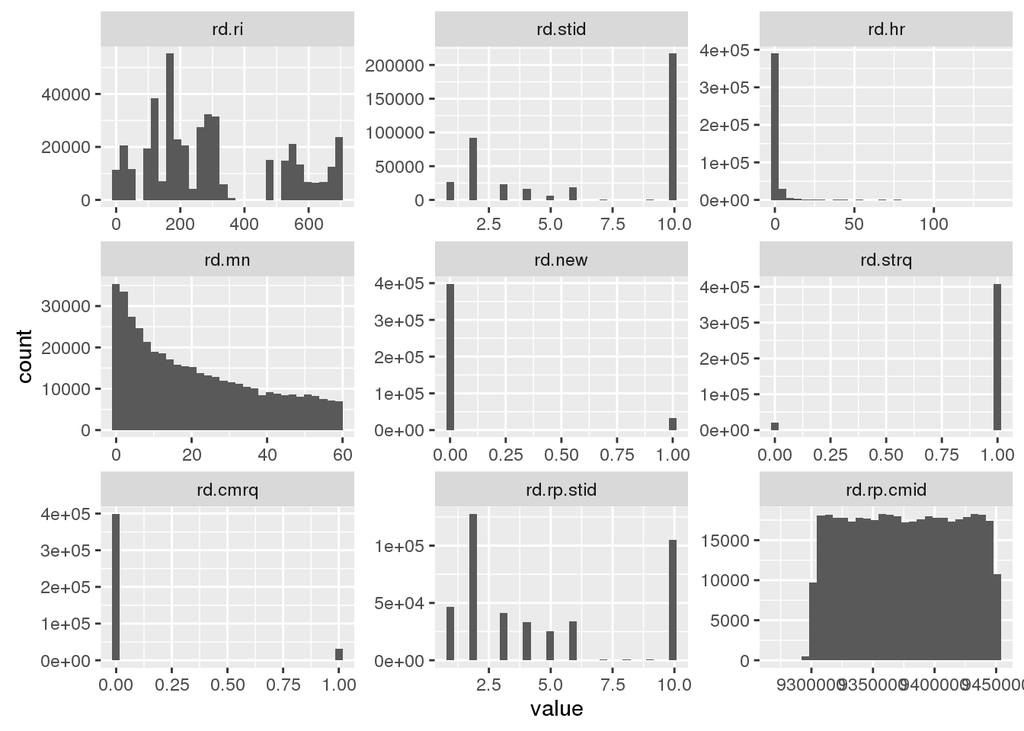

```r
ggplot(d,aes(x = value)) +
    facet_wrap(~variable,scales = "free") +
    geom_histogram()
```

Checking uniqueness of each column value.

```r
uniqueness = sapply(mydata, function(x) length(unique(x)))
```

The dimension of interest is the traffic density. The metrics are the road status id provided by bey2ollak and the hour of day and the week of day.  
By taking a look at the html of the bey2ollak website, we can find out that

| Default Comment | Corresponding stid |
| --- | --- |
| 7alawa: | 1 |
| lazeez: | 2 |
| mashy: | 3 |
| za7ma: | 4 |
| mafeesh 2amal: | 5 |

Extracting the hour of the day from the calculated time of the report.  
Turning the hour of day and week day into factors with discrete levels.  
Extracting data based on only on the five different road status IDs provided above.

```r
t.str <- strptime(mydata$calculated_cairo_date, "%Y-%m-%d %H:%M:%S")
mydata$Hour.Of.Day <- as.numeric(format(t.str, "%H"))
mydata$Day.Of.Week <- factor(mydata$Day.Of.Week)
mydata$Hour.Of.Day <- factor(mydata$Hour.Of.Day)
#mydata$rd.stid <- factor(mydata$rd.stid, ordered = T)
traffic_status <- subset(mydata, mydata$rd.stid %in% c(1,2,3,4,5))
```

Trying to plot the state of the traffic based on the mean of the provided status ids on the different days of the week. The higher the mean, the higher the traffic density.

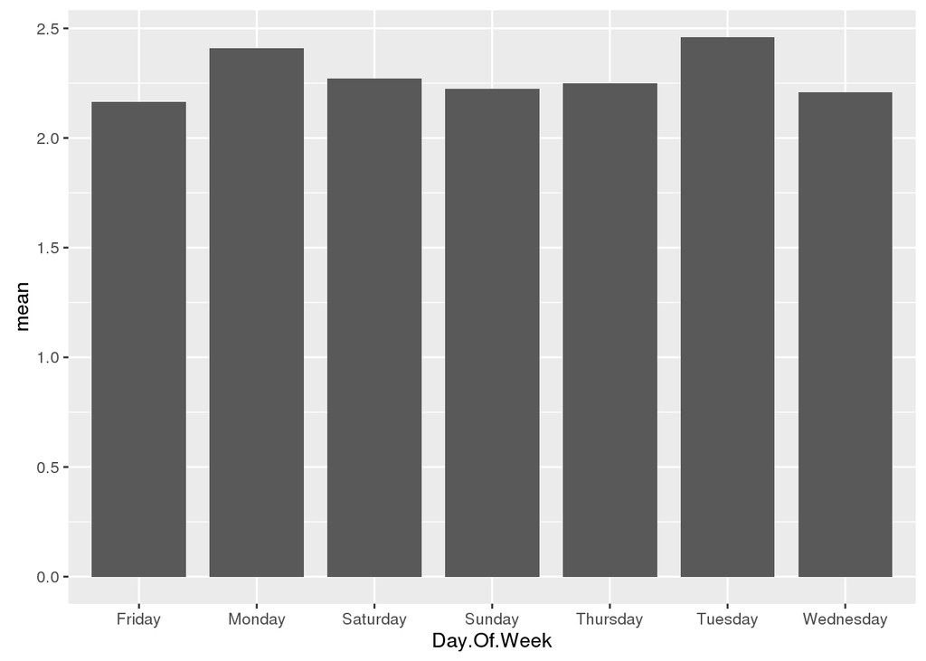

```r
# ggplot(data = traffic_status, aes(x=Day.Of.Week)) + geom_histogram(aes(weights= density, fill=rd.stid)) + scale_fill_brewer(palette="Set3") + facet_wrap( ~ rd.stid, ncol=1)
Traffic_weekDay <- traffic_status %>% group_by(Day.Of.Week) %>% summarise(mean = mean(rd.stid))
Traffic_weekDay%>% ggplot(aes(x=Day.Of.Week, y=mean)) + geom_bar(stat="identity", width = 0.8)
```

Trying to plot the state of the traffic based on the mean of the provided status ids on the different hours of the day.

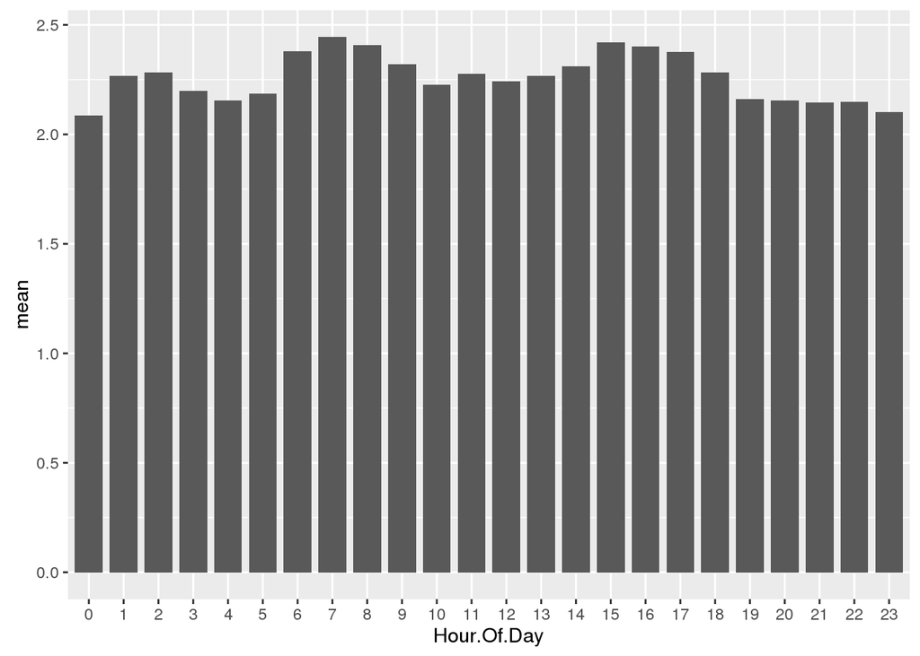

```r
Traffic_hour <- traffic_status %>% group_by(Hour.Of.Day) %>% summarise(mean = mean(rd.stid))
Traffic_hour%>% ggplot(aes(x=Hour.Of.Day, y=mean)) + geom_bar(stat="identity", width = 0.8)
```

Frequency of reporting days.

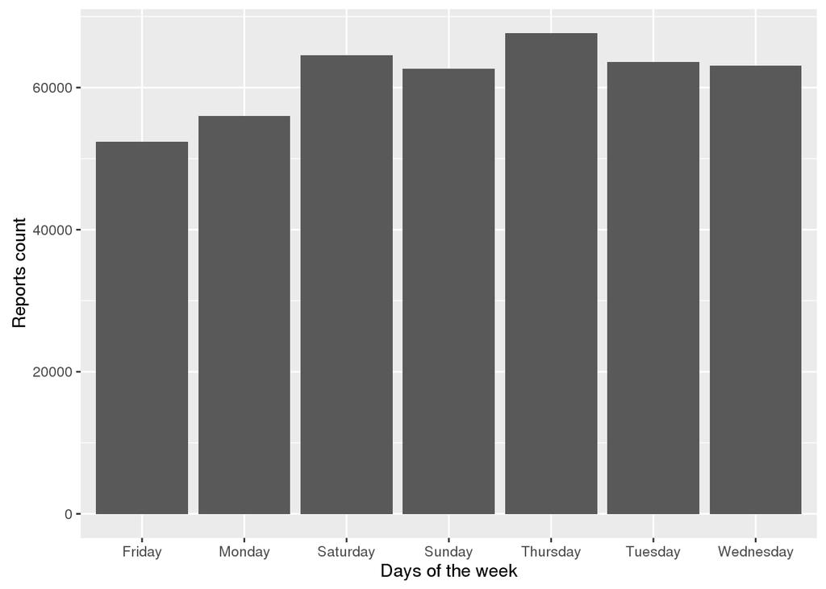

```r
qplot(mydata$Day.Of.Week, xlab = "Days of the week", ylab = "Reports count")
```